# Project 2: Group 4

Group 4: Ben Kopchick, Aditi Seth, Yaochen Zhang, Robert Rapena

May 1, 2017

The question that we are investigating and trying to answer is: Can we predict a country’s CO2 output per capita based on certain factors?

```r
#First we need to define all the packages that we will be using in order to answer our question.
library(ggplot2)
library(tidyr)
library(doBy)
library(reshape2)
library(bestglm)
library(ROCR)
library(plm)
library(corrplot)
library(Hmisc)
```

Now we must load in all of our data for analysis. The factors we chose to check were the countries alternative energy as a percent of the total energy, gdp, gdp growth, gdp per capita, gdp per capita growth, population, population density, population growth, urban population growth, and urban population as a percentage of the population. All of our data was collected from the The World Band DataBank and all countries available were selected.

```r
alt_energy_per_tot <- data.frame(read.csv("DataNew/alt_energy_percentage_of_total.csv"))
co2_emissions <- data.frame(read.csv("DataNew/CO2_emissions_per_capita.csv"))
gdp <- data.frame(read.csv("DataNew/GDP.csv"))
gdp_growth <- data.frame(read.csv("DataNew/GDP_growth.csv"))
gdp_per_capita <- data.frame(read.csv("DataNew/GDP_per_capita.csv"))
gdp_per_capita_growth <- data.frame(read.csv("DataNew/GDP_per_capita_growth.csv"))
pop <- data.frame(read.csv("DataNew/Population.csv"))
pop_den <- data.frame(read.csv("DataNew/population_density.csv"))
pop_growth <- data.frame(read.csv("DataNew/Population_growth.csv"))
urb_pop_growth <- data.frame(read.csv("DataNew/urban_population_growth.csv"))
urb_pop_per <- data.frame(read.csv("DataNew/Urban_population_percentage.csv"))
```

We then need do some data cleaning and rearranging for our data analysis. To do this we need to convert our data to long format for R to read it correctly.

```r
alt_energy_per_tot_long <- gather(alt_energy_per_tot, year, alt_energy_per_tot, X1992:X2013, factor_key = TRUE)
alt_energy_per_tot_long <- alt_energy_per_tot_long[-1]
names(alt_energy_per_tot_long)[1] <- "country"
head(alt_energy_per_tot_long)
```

```
##   country  year alt_energy_per_tot
## 1     AFG X1992                 NA
## 2     ALB X1992        20.42684655
## 3     DZA X1992         0.07124591
## 4     ASM X1992                 NA
## 5     AND X1992                 NA
## 6     AGO X1992         1.19254501
```

```r
co2_emissions_long <- gather(co2_emissions, year, co2, X1992:X2013, factor_key = TRUE)
co2_emissions_long <- co2_emissions_long[-1]
names(co2_emissions_long)[1] <- "country"
head(co2_emissions_long)
```

```
##   country  year       co2
## 1     AFG X1992 0.1013748
## 2     ALB X1992 0.7747249
## 3     DZA X1992 2.9759975
## 4     ASM X1992        NA
## 5     AND X1992        NA
## 6     AGO X1992 0.4385308
```

```r
gdp_long <- gather(gdp, year, gdp, X1992:X2013, factor_key = TRUE)
gdp_long <- gdp_long[-1]
names(gdp_long)[1] <- "country"
head(gdp_long)
```

```
##   country  year         gdp
## 1     AFG X1992          NA
## 2     ALB X1992   709452584
## 3     DZA X1992 48003298223
## 4     ASM X1992          NA
## 5     AND X1992  1210013652
## 6     AGO X1992          NA
```

```r
gdp_growth_long <- gather(gdp_growth, year, gdp_growth, X1992:X2013, factor_key = TRUE)
gdp_growth_long <- gdp_growth_long[-1]
names(gdp_growth_long)[1] <- "country"
head(gdp_growth_long)
```

```
##   country  year gdp_growth
## 1     AFG X1992         NA
## 2     ALB X1992  -7.200000
## 3     DZA X1992   1.800002
## 4     ASM X1992         NA
## 5     AND X1992   0.929212
## 6     AGO X1992  -6.900000
```

```r
gdp_per_capita_long <- gather(gdp_per_capita, year, gdp_per_capita, X1992:X2013, factor_key = TRUE)
gdp_per_capita_long <- gdp_per_capita_long[-1]
names(gdp_per_capita_long)[1] <- "country"
head(gdp_per_capita_long)
```

```
##   country  year gdp_per_capita
## 1     AFG X1992             NA
## 2     ALB X1992       218.4922
## 3     DZA X1992      1766.0659
## 4     ASM X1992             NA
## 5     AND X1992     20542.1305
## 6     AGO X1992             NA
```

```r
gdp_per_capita_growth_long <- gather(gdp_per_capita_growth, year, gdp_per_capita_growth, X1992:X2013, factor_key = TRUE)
gdp_per_capita_growth_long <- gdp_per_capita_growth_long[-1]
names(gdp_per_capita_growth_long)[1] <- "country"
head(gdp_per_capita_growth_long)
```

```
##   country  year gdp_per_capita_growth
## 1     AFG X1992                    NA
## 2     ALB X1992            -6.6355187
## 3     DZA X1992            -0.5469513
## 4     ASM X1992                    NA
## 5     AND X1992            -2.8917873
## 6     AGO X1992            -9.8605857
```

```r
pop_long <- gather(pop, year, pop, X1992:X2013, factor_key = TRUE)
pop_long <- pop_long[-1]
names(pop_long)[1] <- "country"
head(pop_long)
```

```
##   country  year      pop
## 1     AFG X1992 13745630
## 2     ALB X1992  3247039
## 3     DZA X1992 27180921
## 4     ASM X1992    49597
## 5     AND X1992    58904
## 6     AGO X1992 11848971
```

```r
pop_den_long <- gather(pop_den, year, pop_den, X1992:X2013, factor_key = TRUE)
pop_den_long <- pop_den_long[-1]
names(pop_den_long)[1] <- "country"
head(pop_den_long)
```

```
##   country  year    pop_den
## 1     AFG X1992  21.054483
## 2     ALB X1992 118.505073
## 3     DZA X1992  11.412212
## 4     ASM X1992 247.985000
## 5     AND X1992 125.327660
## 6     AGO X1992   9.504268
```

```r
pop_growth_long <- gather(pop_growth, year, pop_growth, X1992:X2013, factor_key = TRUE)
pop_growth_long <- pop_growth_long[-1]
names(pop_growth_long)[1] <- "country"
head(pop_growth_long)
```

```
##   country  year pop_growth
## 1     AFG X1992  7.2106286
## 2     ALB X1992 -0.6064347
## 3     DZA X1992  2.3324466
## 4     ASM X1992  2.4864513
## 5     AND X1992  3.8593448
## 6     AGO X1992  3.2316664
```

```r
urb_pop_growth_long <- gather(urb_pop_growth, year, urb_pop_growth, X1992:X2013, factor_key = TRUE)
urb_pop_growth_long <- urb_pop_growth_long[-1]
names(urb_pop_growth_long)[1] <- "country"
head(urb_pop_growth_long)
```

```
##   country  year urb_pop_growth
## 1     AFG X1992      8.7315101
## 2     ALB X1992      0.8784304
## 3     DZA X1992      3.8081418
## 4     ASM X1992      3.5825689
## 5     AND X1992      3.6417641
## 6     AGO X1992      5.6840908
```

```r
urb_pop_per_long <- gather(urb_pop_per, year, urb_pop_per, X1992:X2013, factor_key = TRUE)
urb_pop_per_long <- urb_pop_per_long[-1]
names(urb_pop_per_long)[1] <- "country"
head(urb_pop_per_long)
```

```
##   country  year urb_pop_per
## 1     AFG X1992      18.882
## 2     ALB X1992      37.249
## 3     DZA X1992      53.657
## 4     ASM X1992      82.789
## 5     AND X1992      94.324
## 6     AGO X1992      26.872
```

All of our data is then merged into one data frame.

```r
total_btw <- merge(alt_energy_per_tot_long,co2_emissions_long,by=c("year","country")) #Couldn't merge three files at once so we had to do this in two steps.
total_btw2 <- merge(total_btw, gdp_long,by=c("year","country"))
total_btw3 <- merge(total_btw2, gdp_growth_long,by=c("year","country"))
total_btw4 <- merge(total_btw3, gdp_per_capita_long, by=c("year","country"))
total_btw5 <- merge(total_btw4, gdp_per_capita_growth_long, by=c("year","country"))
total_btw6 <- merge(total_btw5, pop_long, by=c("year", "country"))
total_btw7 <- merge(total_btw6, pop_den_long, by=c("year", "country"))
total_btw8 <- merge(total_btw7, pop_growth_long, by=c("year", "country"))
total_btw9 <- merge(total_btw8, urb_pop_growth_long, by=c("year", "country"))
total <- merge(total_btw9, urb_pop_per_long, by=c("year","country"))
head(total)
```

```
##    year country alt_energy_per_tot        co2         gdp gdp_growth
## 1 X1992     ABW                 NA 22.8398183          NA         NA
## 2 X1992     AFG                 NA  0.1013748          NA         NA
## 3 X1992     AGO           1.192545  0.4385308          NA  -6.900000
## 4 X1992     ALB          20.426847  0.7747249   709452584  -7.200000
## 5 X1992     AND                 NA         NA  1210013652   0.929212
## 6 X1992     ARE           0.000000 28.7945591 54239171888   3.344945
##   gdp_per_capita gdp_per_capita_growth      pop    pop_den pop_growth
## 1             NA                    NA    68235 379.083333  5.4387245
## 2             NA                    NA 13745630  21.054483  7.2106286
## 3             NA             -9.860586 11848971   9.504268  3.2316664
## 4       218.4922             -6.635519  3247039 118.505073 -0.6064347
## 5     20542.1305             -2.891787    58904 125.327660  3.8593448
## 6     26864.1881             -2.071746  2019014  24.150885  5.3837267
##   urb_pop_growth urb_pop_per
## 1      4.8280270      49.998
## 2      8.7315101      18.882
## 3      5.6840908      26.872
## 4      0.8784304      37.249
## 5      3.6417641      94.324
## 6      5.1984785      78.760
```

We notice that a lot of our data is missing values (NA). We therefore decided to omit all countries that were missing data. Because we are using 22 years each country should have 22 years of data for each variable. If they do not then we cut the country.

```r
totalomit <- na.omit(total)
head(totalomit)
```

```
##     year country alt_energy_per_tot        co2          gdp gdp_growth
## 4  X1992     ALB          20.426847  0.7747249    709452584  -7.200000
## 6  X1992     ARE           0.000000 28.7945591  54239171888   3.344945
## 7  X1992     ARG           7.032315  3.6085822 228789000000  11.940775
## 8  X1992     ARM           6.337680  1.5998956   1272577522 -41.800003
## 11 X1992     AUS           1.613881 15.3177685 325253000000   0.399007
## 12 X1992     AUT          11.906027  7.2262364 194608000000   2.093525
##    gdp_per_capita gdp_per_capita_growth      pop    pop_den pop_growth
## 4        218.4922            -6.6355187  3247039 118.505073 -0.6064347
## 6      26864.1881            -2.0717464  2019014  24.150885  5.3837267
## 7       6798.0272            10.4066757 33655149  12.297757  1.3799334
## 8        368.9168           -40.7469354  3449497 121.162522 -1.7932195
## 11     18591.2205            -0.8118641 17495000   2.277313  1.2133908
## 12     24820.2278             0.9760923  7840709  94.946827  1.1005523
##    urb_pop_growth urb_pop_per
## 4       0.8784304      37.249
## 6       5.1984785      78.760
## 7       1.6246899      87.542
## 8      -2.1990921      66.878
## 11      1.4075835      85.566
## 12      1.1005670      65.800
```

```r
newtotal <- totalomit[totalomit$country %in% names(table(totalomit$country))[table(totalomit$country) >= 22],]
head(newtotal)
```

```
##     year country alt_energy_per_tot        co2          gdp gdp_growth
## 4  X1992     ALB          20.426847  0.7747249    709452584  -7.200000
## 6  X1992     ARE           0.000000 28.7945591  54239171888   3.344945
## 7  X1992     ARG           7.032315  3.6085822 228789000000  11.940775
## 8  X1992     ARM           6.337680  1.5998956   1272577522 -41.800003
## 11 X1992     AUS           1.613881 15.3177685 325253000000   0.399007
## 12 X1992     AUT          11.906027  7.2262364 194608000000   2.093525
##    gdp_per_capita gdp_per_capita_growth      pop    pop_den pop_growth
## 4        218.4922            -6.6355187  3247039 118.505073 -0.6064347
## 6      26864.1881            -2.0717464  2019014  24.150885  5.3837267
## 7       6798.0272            10.4066757 33655149  12.297757  1.3799334
## 8        368.9168           -40.7469354  3449497 121.162522 -1.7932195
## 11     18591.2205            -0.8118641 17495000   2.277313  1.2133908
## 12     24820.2278             0.9760923  7840709  94.946827  1.1005523
##    urb_pop_growth urb_pop_per
## 4       0.8784304      37.249
## 6       5.1984785      78.760
## 7       1.6246899      87.542
## 8      -2.1990921      66.878
## 11      1.4075835      85.566
## 12      1.1005670      65.800
```

We need to do just a little more data cleaning/fixing. Due to how R reads in the data, it changed our year values to factors and therefore we need to change that back.

```r
newtotal$year <- as.numeric(newtotal$year) + 1991
summary(newtotal)
```

```
##       year         country     alt_energy_per_tot      co2
##  Min.   :1992   ALB    :  22   Min.   : 0.0000    Min.   : 0.04047
##  1st Qu.:1997   ARE    :  22   1st Qu.: 0.7615    1st Qu.: 0.99955
##  Median :2002   ARG    :  22   Median : 3.8037    Median : 3.54335
##  Mean   :2002   ARM    :  22   Mean   : 9.1207    Mean   : 5.28354
##  3rd Qu.:2008   AUS    :  22   3rd Qu.:11.7014    3rd Qu.: 7.87566
##  Max.   :2013   AUT    :  22   Max.   :89.7253    Max.   :36.90410
##                 (Other):2222
##       gdp              gdp_growth      gdp_per_capita
##  Min.   :7.095e+08   Min.   :-44.900   Min.   :   111.5
##  1st Qu.:1.101e+10   1st Qu.:  1.803   1st Qu.:  1043.4
##  Median :4.798e+10   Median :  3.911   Median :  3682.2
##  Mean   :4.033e+11   Mean   :  3.619   Mean   : 11017.0
##  3rd Qu.:2.278e+11   3rd Qu.:  6.021   3rd Qu.: 15631.8
##  Max.   :1.669e+13   Max.   : 34.500   Max.   :102910.4
##
##  gdp_per_capita_growth      pop               pop_den
##  Min.   :-45.3251      Min.   :2.611e+05   Min.   :   1.444
##  1st Qu.:  0.4788      1st Qu.:4.960e+06   1st Qu.:  26.878
##  Median :  2.3452      Median :1.225e+07   Median :  71.691
##  Mean   :  2.1679      Mean   :5.352e+07   Mean   : 237.807
##  3rd Qu.:  4.4749      3rd Qu.:3.866e+07   3rd Qu.: 132.017
##  Max.   : 33.0305      Max.   :1.357e+09   Max.   :7636.721
##
##    pop_growth      urb_pop_growth     urb_pop_per
##  Min.   :-2.6597   Min.   :-3.1026   Min.   :  8.666
##  1st Qu.: 0.5145   1st Qu.: 0.7732   1st Qu.: 43.038
##  Median : 1.3130   Median : 1.8652   Median : 62.240
##  Mean   : 1.4217   Mean   : 2.0551   Mean   : 59.960
##  3rd Qu.: 2.1820   3rd Qu.: 3.1784   3rd Qu.: 77.000
##  Max.   :15.0326   Max.   :15.4805   Max.   :100.000
##
```

We then write this data to a csv file for safe keeping.

```r
write.csv(newtotal, "newtotal.csv")
```

Now we begin with our Exploratory Data Analysis. Here we print out all the information we have based on all the different countries we have chosen over time.

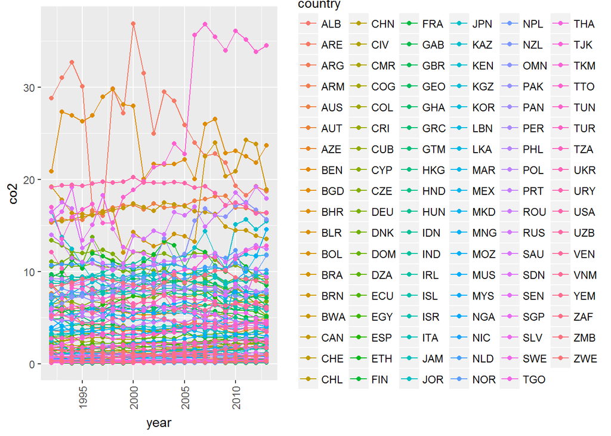

```r
#Our raw data printed out
ggplot(data=newtotal, aes(x=year, y=co2, group=country, colour = country)) + geom_line() + geom_point() + theme(axis.text.x = element_text(angle=90, vjust=.5))
```

To find out if our data is normal we print out the normal Q-Q Plots for our eleven variables.

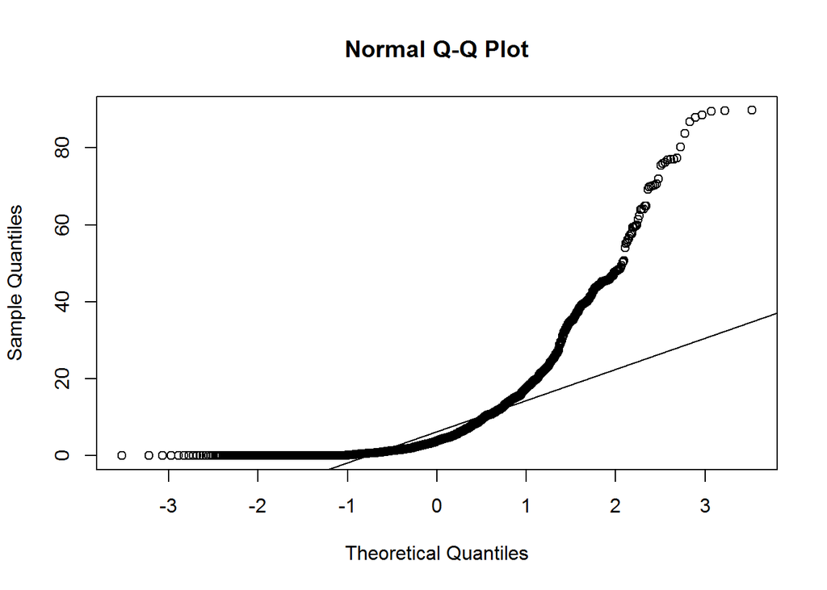

```r
#Q-Q Plots
qqnorm(newtotal$alt_energy_per_tot)
qqline(newtotal$alt_energy_per_tot)
```

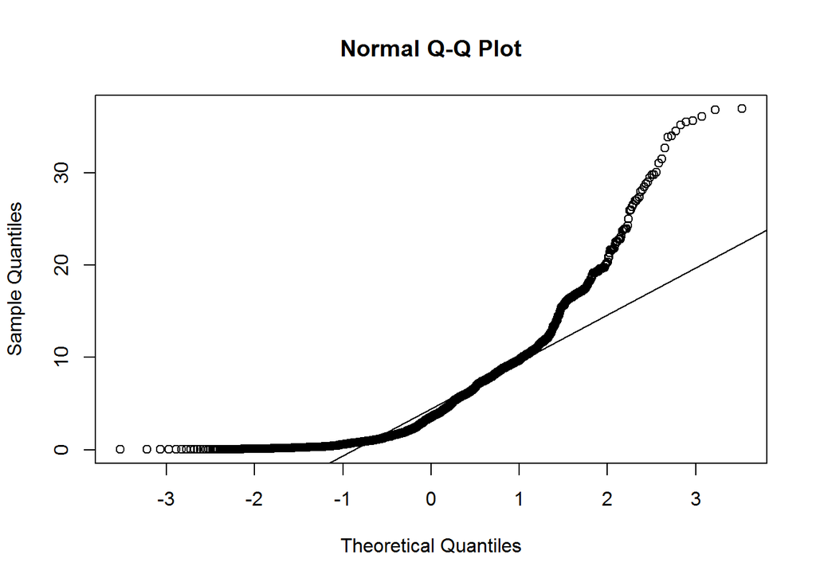

```r
qqnorm(newtotal$co2)
qqline(newtotal$co2)
```

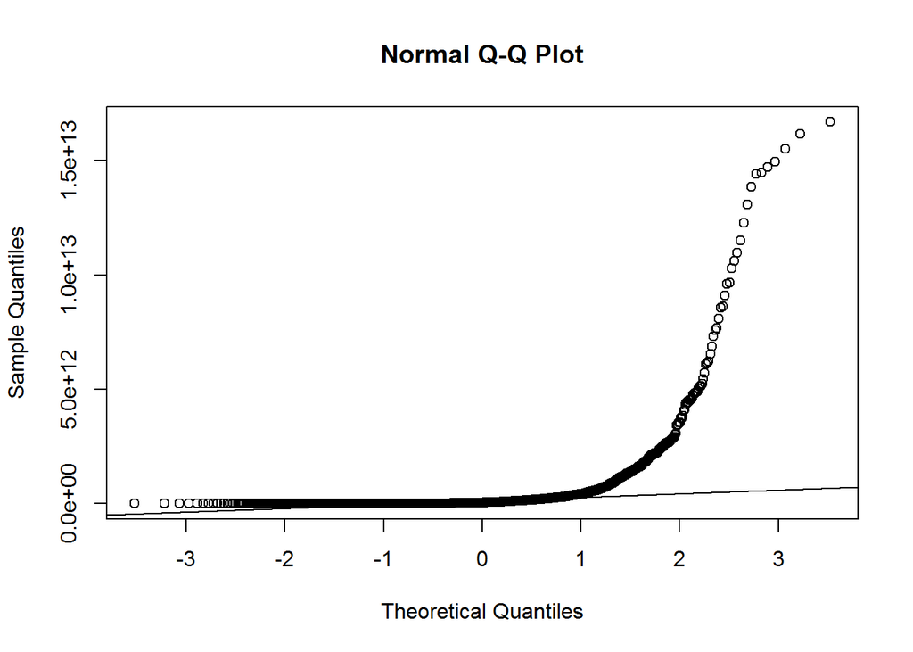

```r
qqnorm(newtotal$gdp)
qqline(newtotal$gdp)
```

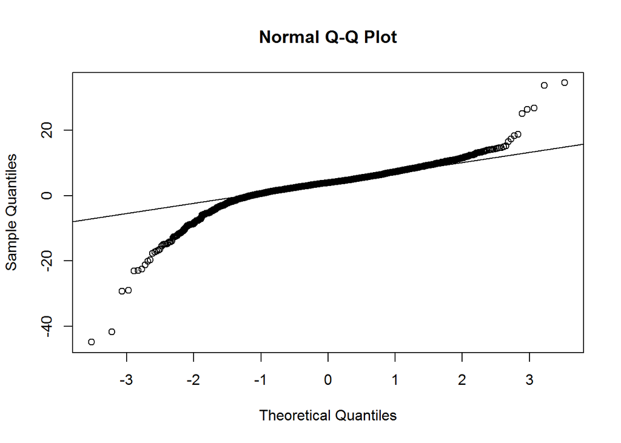

```r
qqnorm(newtotal$gdp_growth)
qqline(newtotal$gdp_growth)
```

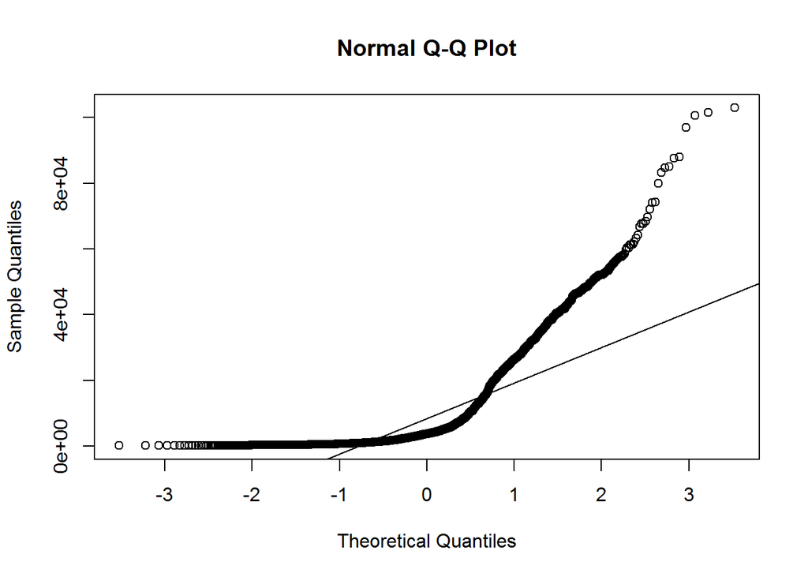

```r
qqnorm(newtotal$gdp_per_capita)
qqline(newtotal$gdp_per_capita)
```

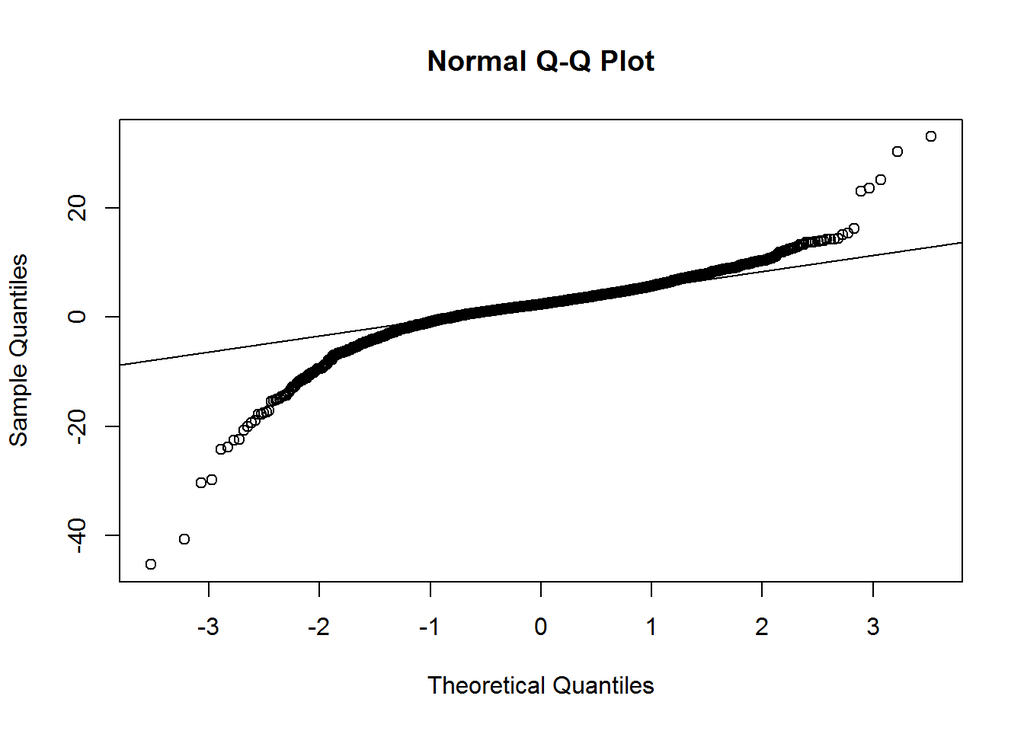

```r
qqnorm(newtotal$gdp_per_capita_growth)
qqline(newtotal$gdp_per_capita_growth)
```

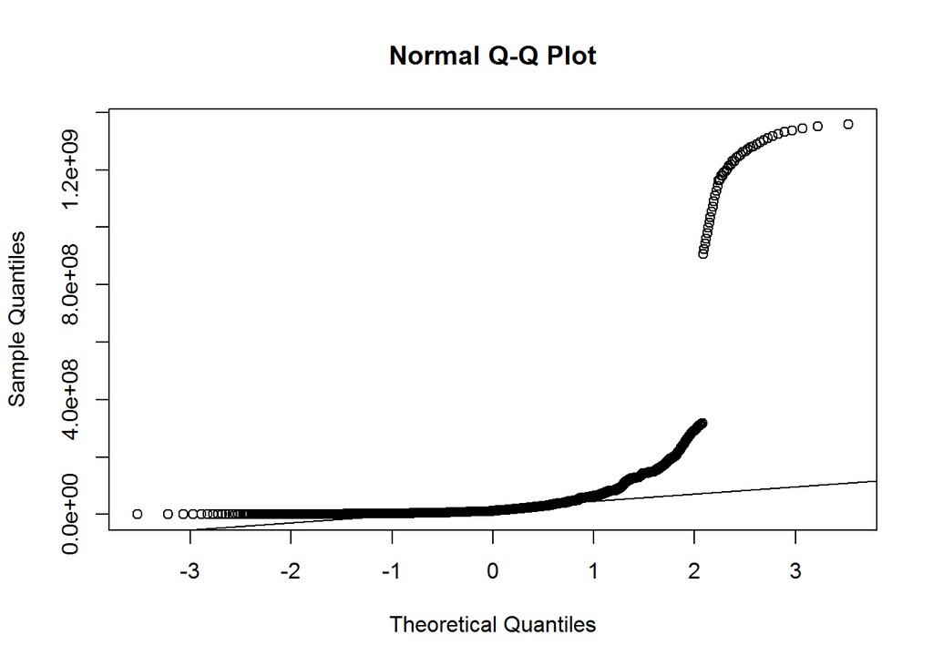

```r
qqnorm(newtotal$pop)
qqline(newtotal$pop)
```

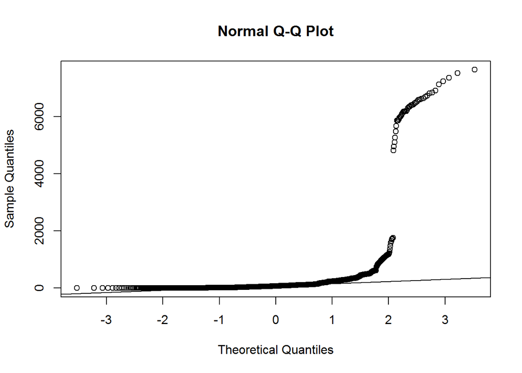

```r
qqnorm(newtotal$pop_den)
qqline(newtotal$pop_den)
```

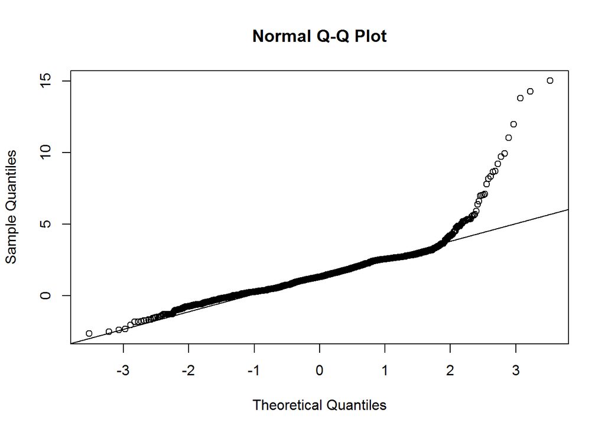

```r
qqnorm(newtotal$pop_growth)
qqline(newtotal$pop_growth)
```

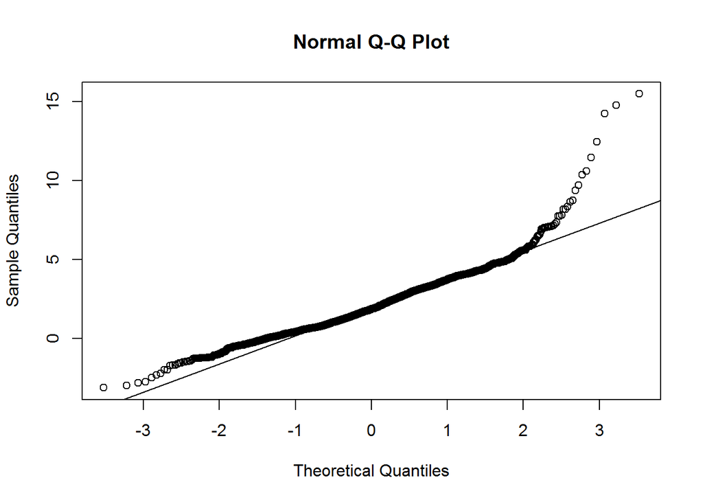

```r
qqnorm(newtotal$urb_pop_growth)
qqline(newtotal$urb_pop_growth)
```

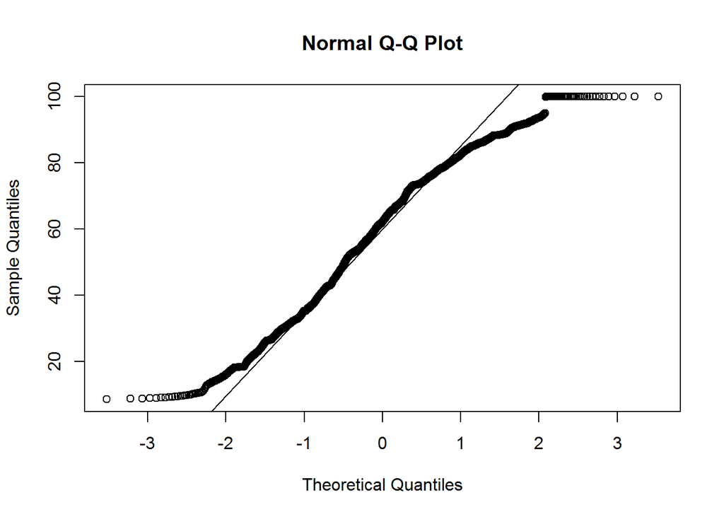

```r
qqnorm(newtotal$urb_pop_per)
qqline(newtotal$urb_pop_per)
```

We also look at the histograms of the data.

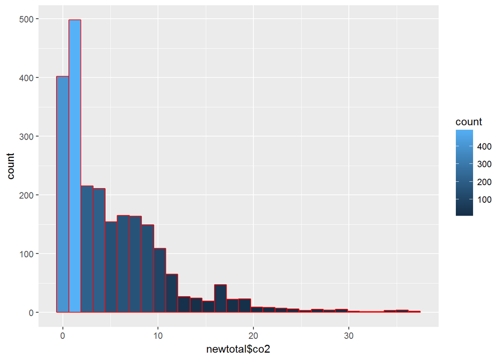

```r
#Simple histograms split into the eleven variables
ggplot(data=data.frame(newtotal$co2), aes(newtotal$co2)) +
  geom_histogram(col='red', aes(fill=..count..))
```

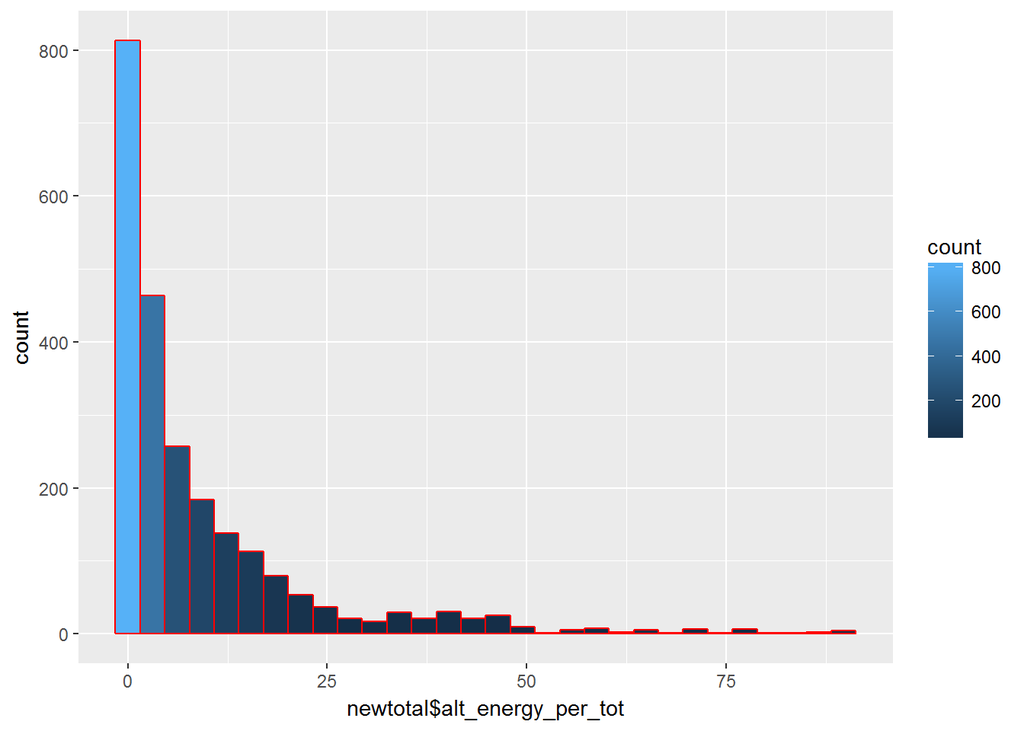

```r
ggplot(data=data.frame(newtotal$alt_energy_per_tot), aes(newtotal$alt_energy_per_tot)) +
  geom_histogram(col='red', aes(fill=..count..))
```

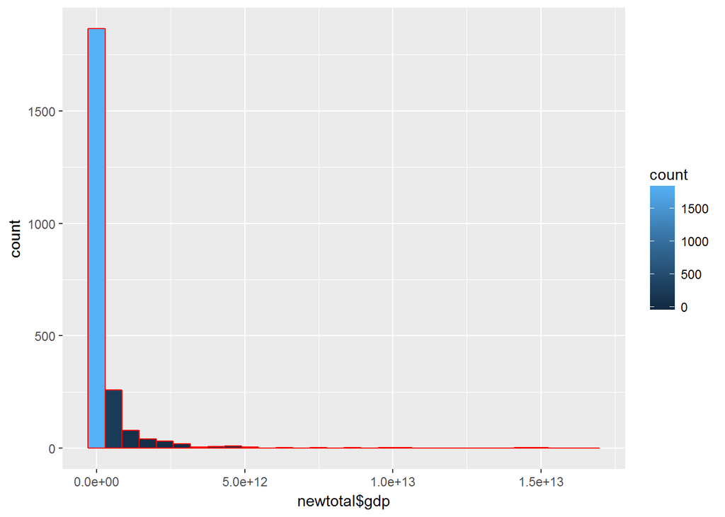

```r
ggplot(data=data.frame(newtotal$gdp), aes(newtotal$gdp)) +
  geom_histogram(col='red', aes(fill=..count..))
```

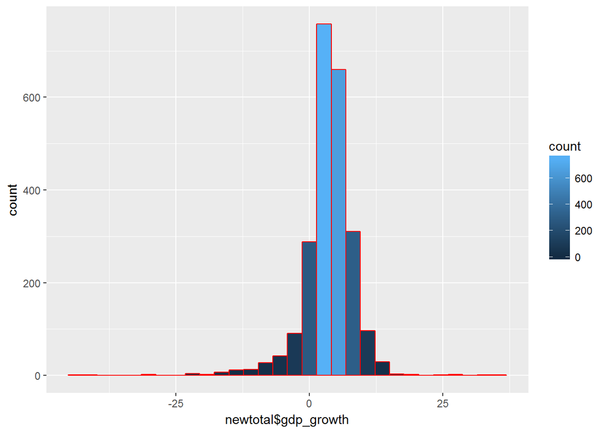

```r
ggplot(data=data.frame(newtotal$gdp_growth), aes(newtotal$gdp_growth)) +
  geom_histogram(col='red', aes(fill=..count..))
```

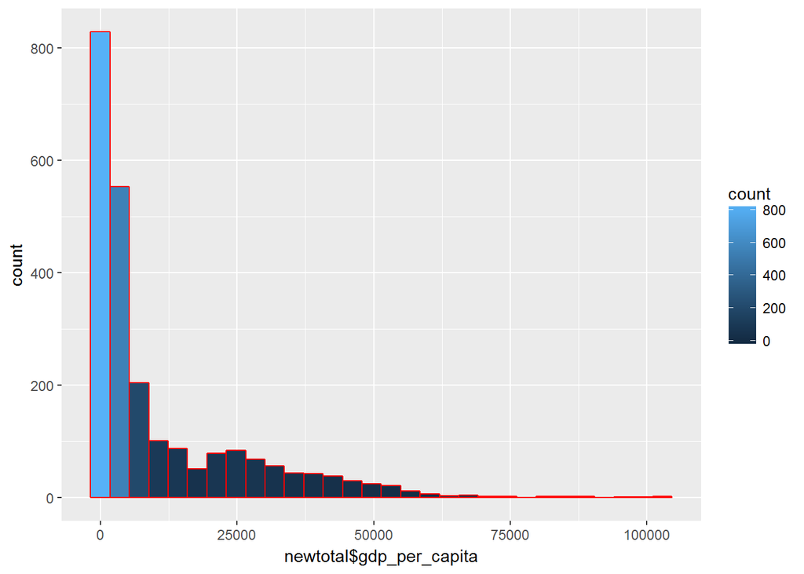

```r
ggplot(data=data.frame(newtotal$gdp_per_capita), aes(newtotal$gdp_per_capita)) +
  geom_histogram(col='red', aes(fill=..count..))
```

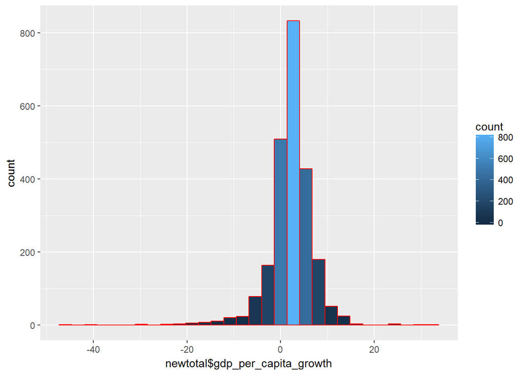

```r
ggplot(data=data.frame(newtotal$gdp_per_capita_growth), aes(newtotal$gdp_per_capita_growth)) +
  geom_histogram(col='red', aes(fill=..count..))
```

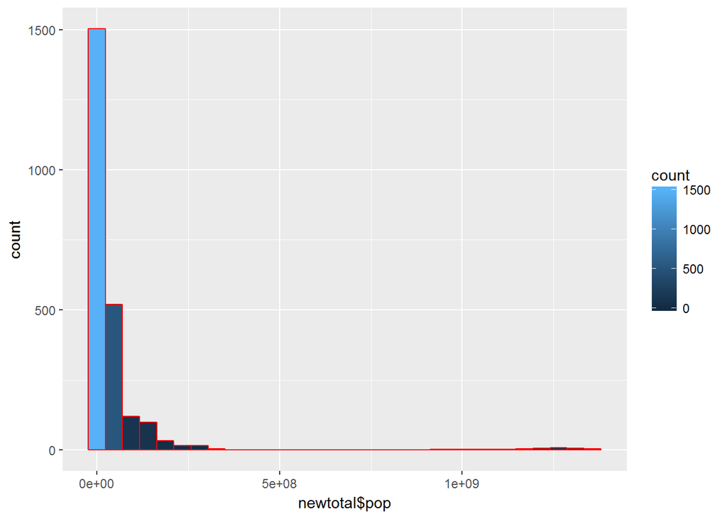

```r
ggplot(data=data.frame(newtotal$pop), aes(newtotal$pop)) +
  geom_histogram(col='red', aes(fill=..count..))
```

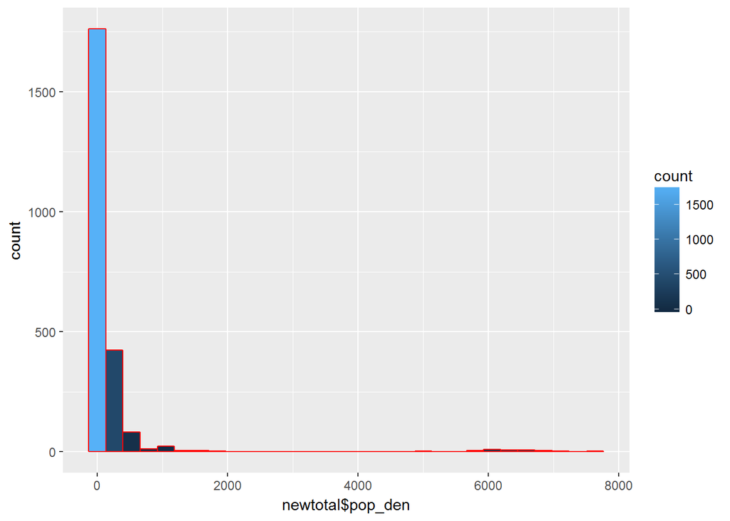

```r
ggplot(data=data.frame(newtotal$pop_den), aes(newtotal$pop_den)) +
  geom_histogram(col='red', aes(fill=..count..))
```

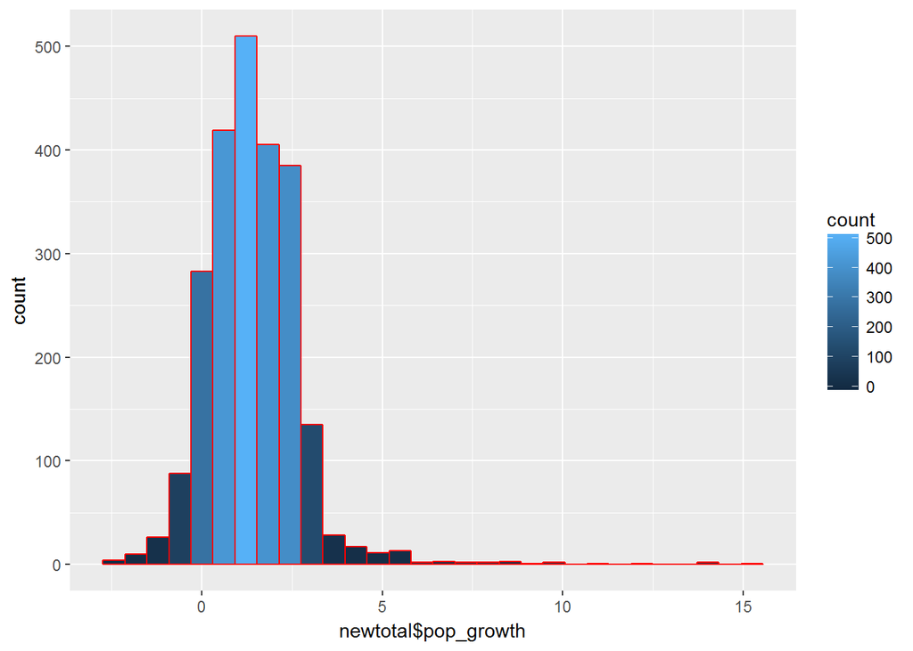

```r
ggplot(data=data.frame(newtotal$pop_growth), aes(newtotal$pop_growth)) +
  geom_histogram(col='red', aes(fill=..count..))
```

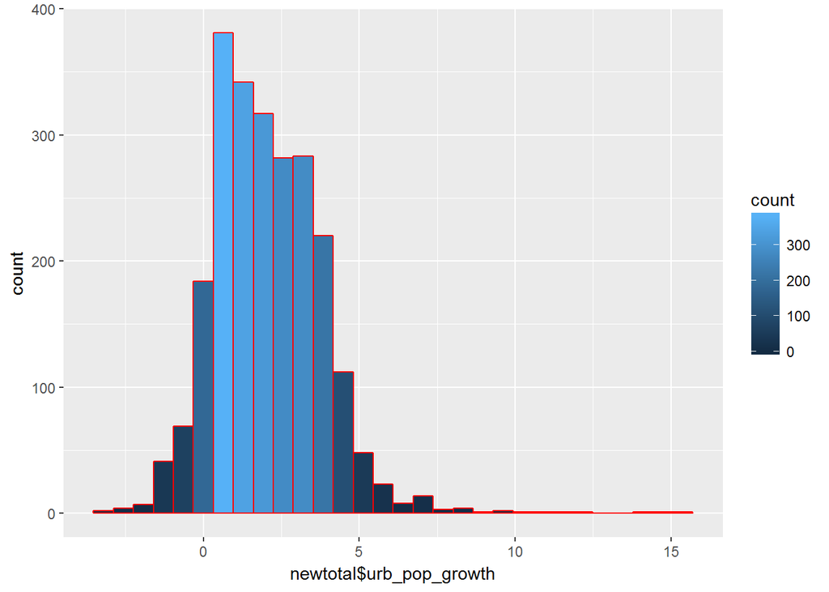

```r
ggplot(data=data.frame(newtotal$urb_pop_growth), aes(newtotal$urb_pop_growth)) +
  geom_histogram(col='red', aes(fill=..count..))
```

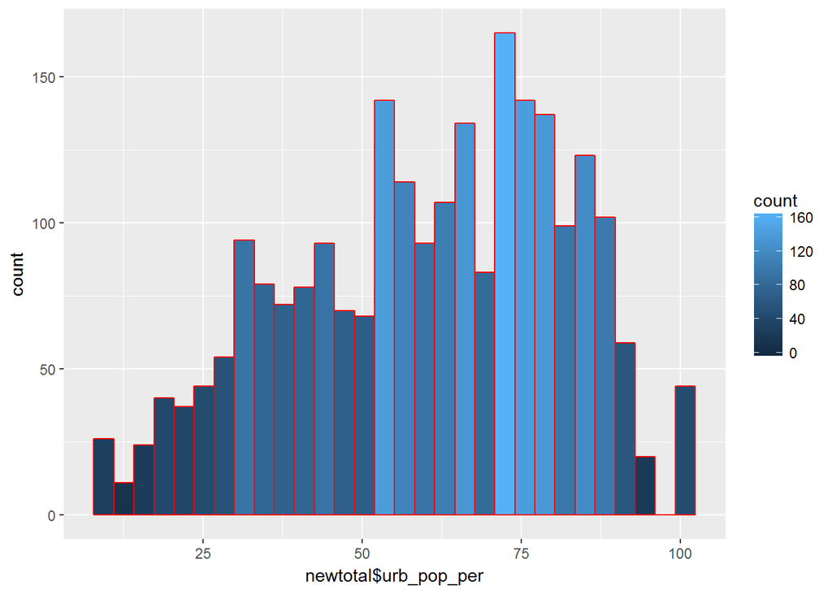

```r
ggplot(data=data.frame(newtotal$urb_pop_per), aes(newtotal$urb_pop_per)) +
  geom_histogram(col='red', aes(fill=..count..))
```

From the data we see that most of our variables are not normal. We move forward with calculating the correlation coefficients. Due to the non-normality of our data we use the spearman method.

```r
library(stats)
library(Hmisc)
# Correlations
x<- newtotal[3:13]
corr <- cor(x,x, method = "spearman")
round(corr, 2)
```

```
##                       alt_energy_per_tot   co2   gdp gdp_growth
## alt_energy_per_tot                  1.00 -0.05  0.23      -0.13
## co2                                -0.05  1.00  0.53      -0.19
## gdp                                 0.23  0.53  1.00      -0.11
## gdp_growth                         -0.13 -0.19 -0.11       1.00
## gdp_per_capita                      0.18  0.81  0.65      -0.22
## gdp_per_capita_growth               0.01 -0.08  0.00       0.92
## pop                                 0.13 -0.13  0.61       0.04
## pop_den                            -0.07  0.01  0.20       0.02
## pop_growth                         -0.35 -0.41 -0.33       0.18
## urb_pop_growth                     -0.37 -0.45 -0.25       0.23
## urb_pop_per                         0.20  0.68  0.48      -0.20
##                       gdp_per_capita gdp_per_capita_growth   pop pop_den
## alt_energy_per_tot              0.18                  0.01  0.13   -0.07
## co2                             0.81                 -0.08 -0.13    0.01
## gdp                             0.65                  0.00  0.61    0.20
## gdp_growth                     -0.22                  0.92  0.04    0.02
## gdp_per_capita                  1.00                 -0.10 -0.15    0.08
## gdp_per_capita_growth          -0.10                  1.00  0.06    0.07
## pop                            -0.15                  0.06  1.00    0.15
## pop_den                         0.08                  0.07  0.15    1.00
## pop_growth                     -0.38                 -0.14 -0.02   -0.21
## urb_pop_growth                 -0.41                 -0.06  0.09   -0.09
## urb_pop_per                     0.79                 -0.13 -0.17   -0.11
##                       pop_growth urb_pop_growth urb_pop_per
## alt_energy_per_tot         -0.35          -0.37        0.20
## co2                        -0.41          -0.45        0.68
## gdp                        -0.33          -0.25        0.48
## gdp_growth                  0.18           0.23       -0.20
## gdp_per_capita             -0.38          -0.41        0.79
## gdp_per_capita_growth      -0.14          -0.06       -0.13
## pop                        -0.02           0.09       -0.17
## pop_den                    -0.21          -0.09       -0.11
## pop_growth                  1.00           0.87       -0.26
## urb_pop_growth              0.87           1.00       -0.35
## urb_pop_per                -0.26          -0.35        1.00
```

We also visualize the correlations.

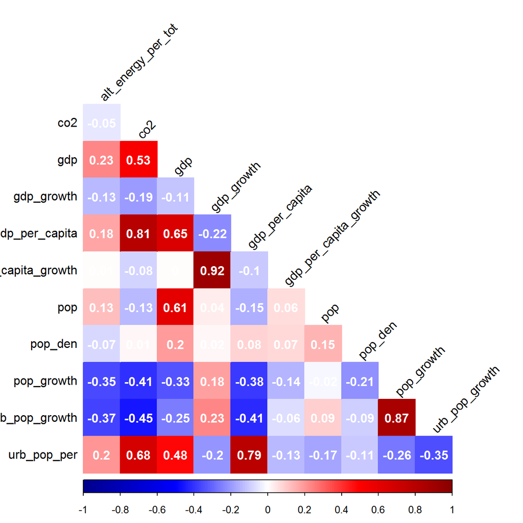

```r
col <- colorRampPalette(c("darkblue", "blue", "white", "red", "darkred"))(200)
corrplot(corr, method = "color", addCoef.col = "white", type = "lower", tl.col = "black",
    tl.srt = 45, col = col, diag = FALSE)
```

Notice that there are some strong correlations between a few of the variables. This may prove a problem and we should remove one of those points to avoid multicollinearity.

Here we print scatterplots to also see any possible correlations.

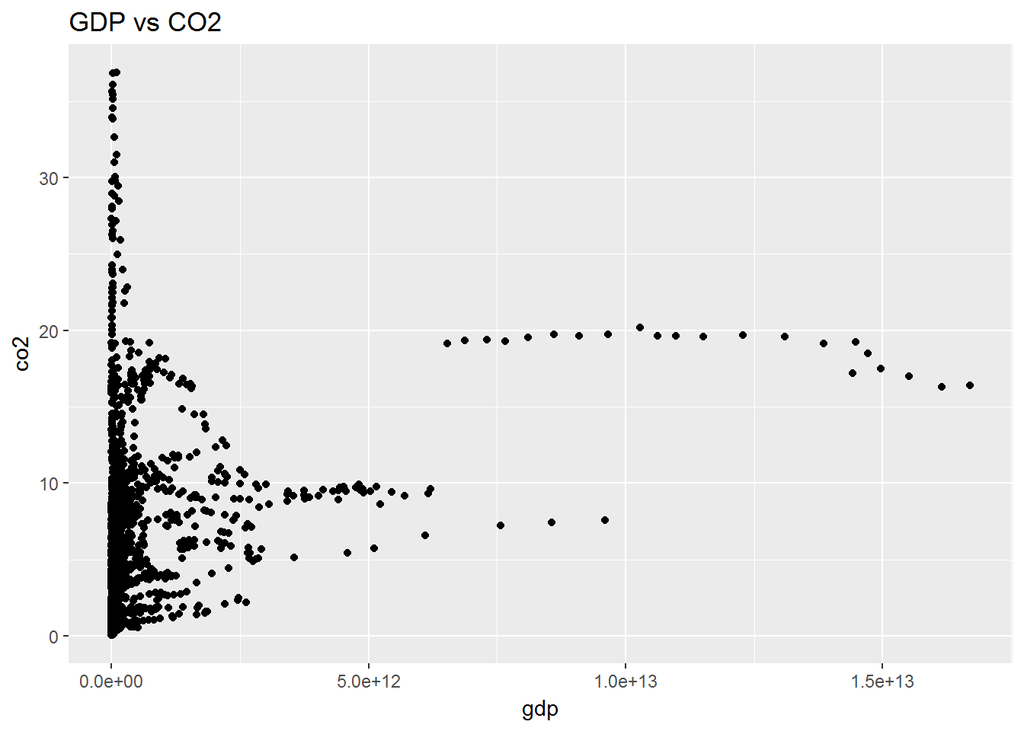

```r
#Simple scatterplots revealing the 9 possible correlations as shown above
ggplot(newtotal, aes(x=gdp, y=co2)) + geom_point() + ggtitle("GDP vs CO2")
```

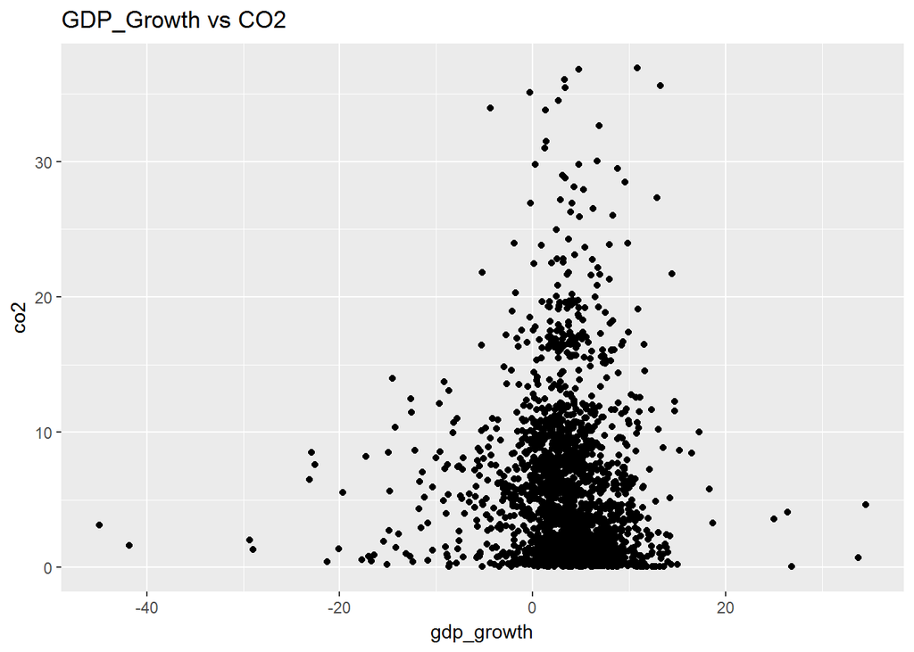

```r
ggplot(newtotal, aes(x=gdp_growth, y=co2)) + geom_point() + ggtitle("GDP_Growth vs CO2")
```

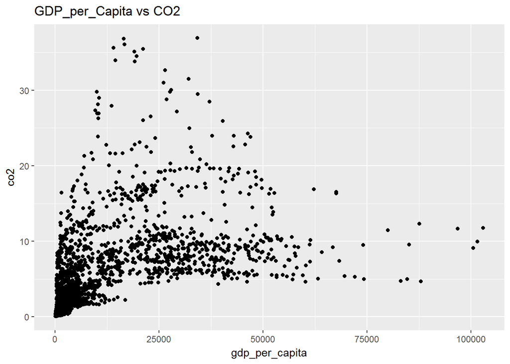

```r
ggplot(newtotal, aes(x=gdp_per_capita, y=co2)) + geom_point() + ggtitle("GDP_per_Capita vs CO2")
```

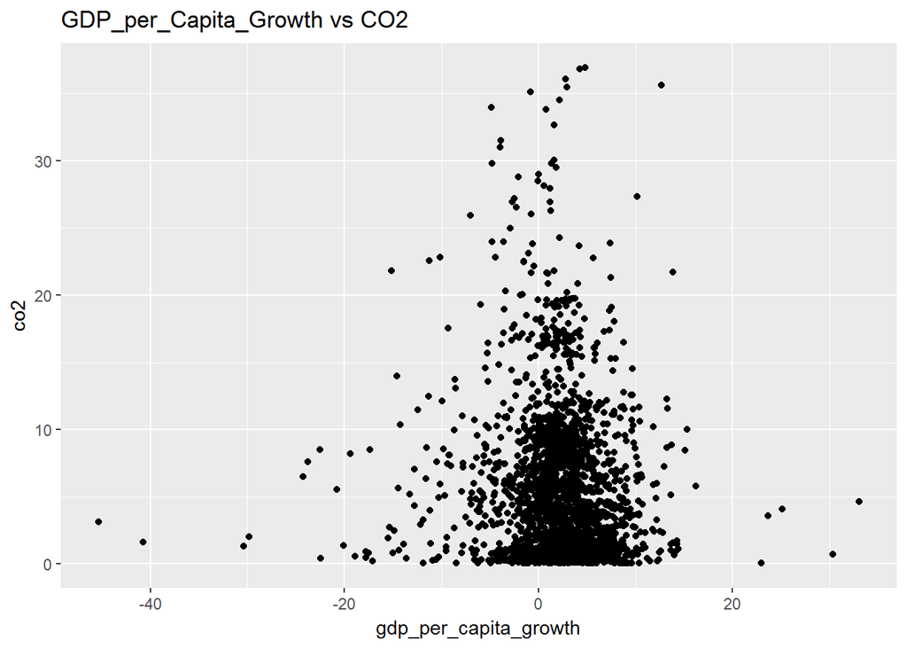

```r
ggplot(newtotal, aes(x=gdp_per_capita_growth, y=co2)) + geom_point() + ggtitle("GDP_per_Capita_Growth vs CO2")
```

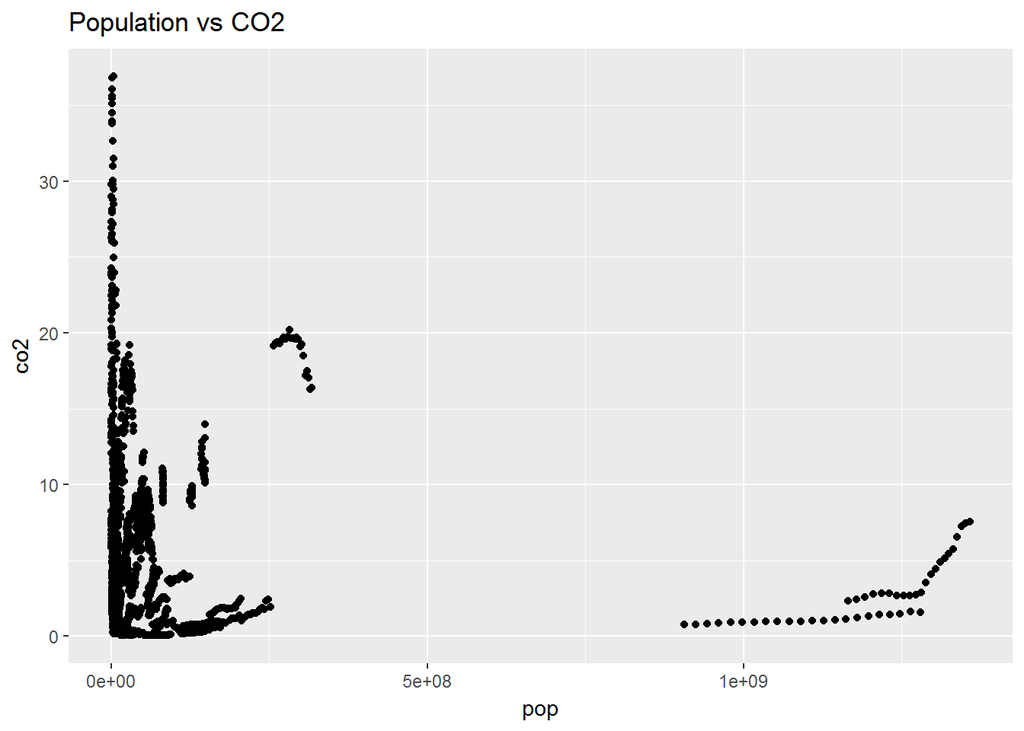

```r
ggplot(newtotal, aes(x=pop, y=co2)) + geom_point() + ggtitle("Population vs CO2")
```

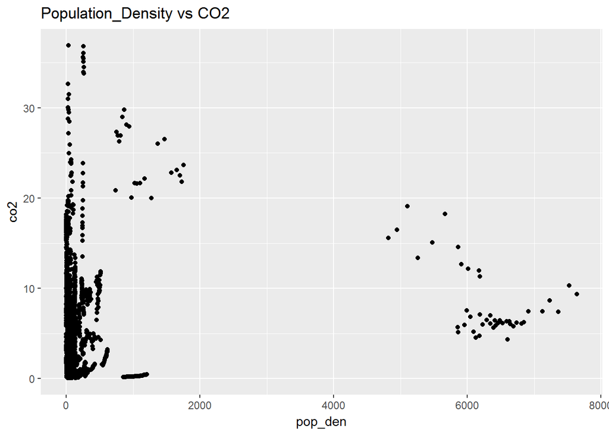

```r
ggplot(newtotal, aes(x=pop_den, y=co2)) + geom_point() + ggtitle("Population_Density vs CO2")
```

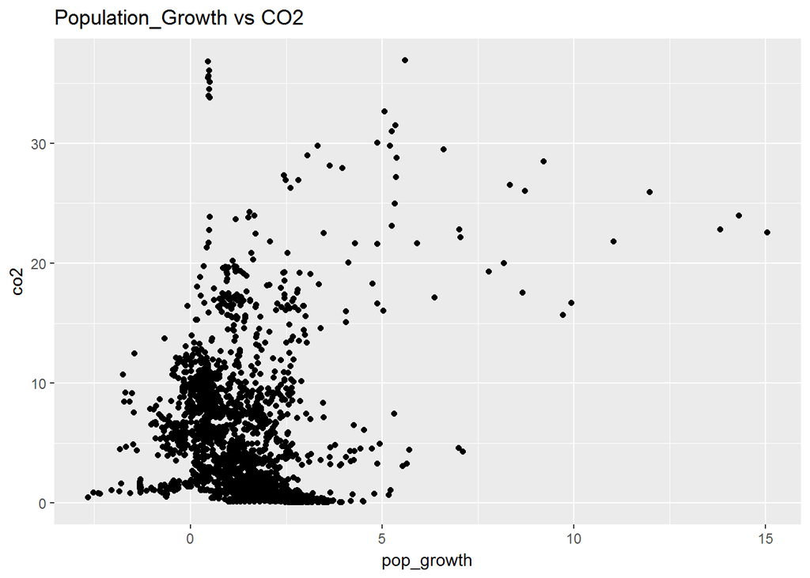

```r
ggplot(newtotal, aes(x=pop_growth, y=co2)) + geom_point() + ggtitle("Population_Growth vs CO2")
```

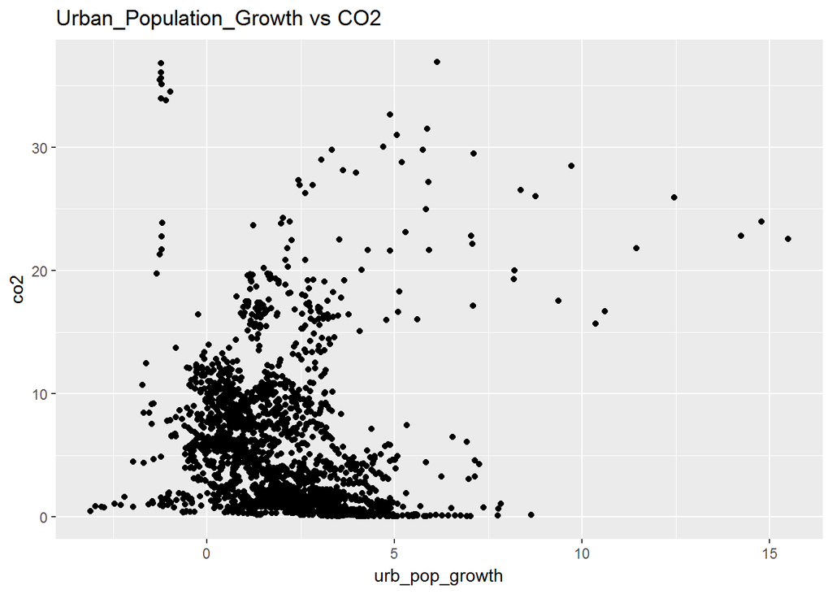

```r
ggplot(newtotal, aes(x=urb_pop_growth, y=co2)) + geom_point() + ggtitle("Urban_Population_Growth vs CO2")
```